# Customized fit

### Plotting

In order to assess for convergence, let's plot useful graphs to visualize the mcmc behavior. As before, let's call the nauyaca's Plots module.

```python
nauplot = nau.Plots(PS, hdf5_file=mcmc.hdf5_filename, burnin=burn, temperature=0)
```

Remember that there's not a unique method to asses for convergence. Although, a visual method is to corroborate the stationarity of the distributions:

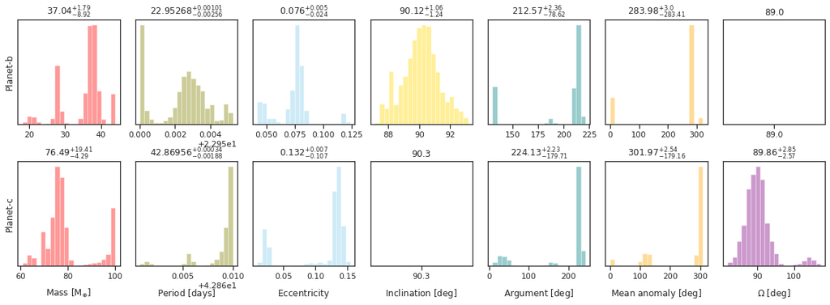

```python
nauplot.hist(titles=True);
```

Make a trace plot of the chain's movement along the iterations. Note in the x-axis that the steps are normalized by the 'intra_steps' kwarg specified in the MCMC module. Change the temperature attribute to show the movement of the other temperatures. However, remember that the posteriors are calculated over temperature 0, the colder chain.

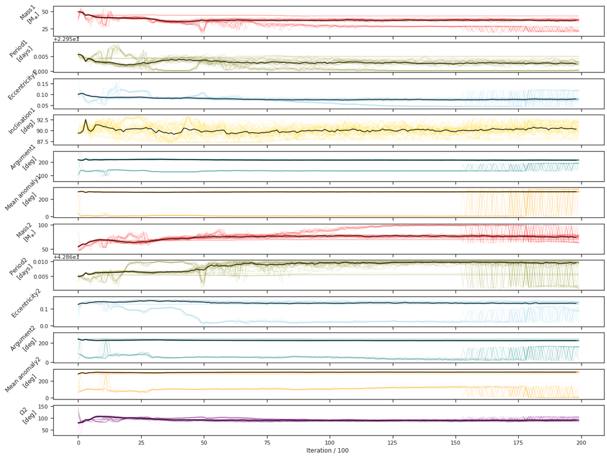

```python
nauplot.temperature = 0

nauplot.trace_plot(plot_means=True);  # Plot a line of the mean
```

Now, let's plot a monitoring of the parallel-tempering mcmc. These panels shows:

```
* Upper left: it shows adaptation of the temperature ladder. The parallel-tempering algoritmh adapts the temperature ladder to improve the efficiency of the communication between walkers at different temperatures. Walkers at hotter temperatures have broader movements along the parameter space, whilst walkers at colder temperatures can explore tight regions. Note that the maximum temperature corresponds to the value in the 'tmax' kwarg in the MCMC module, which by default is fixed. See Vousden et al. (2016) for details.

* Upper right: the swap between walkers at different temperatures. It shows the fraction of walkers at different temperatures that are accepted in other temperature. An asymptotic growing curve represent a good communication exchange. Black line represent the acceptance for the main temperature.

* Lower left: the improvement of the log posterior. It allow us to visualize the asymptotic improvement of the log posterior averaged along all the solutions (blue line) and the maximum a posteriori (orange line) reached at each step. This panel could help you to decide the fractional burning length.

* Lower right: the mean autocorrelation time averaged along all dimensions. It would be useful to determine the effective sample size.
```

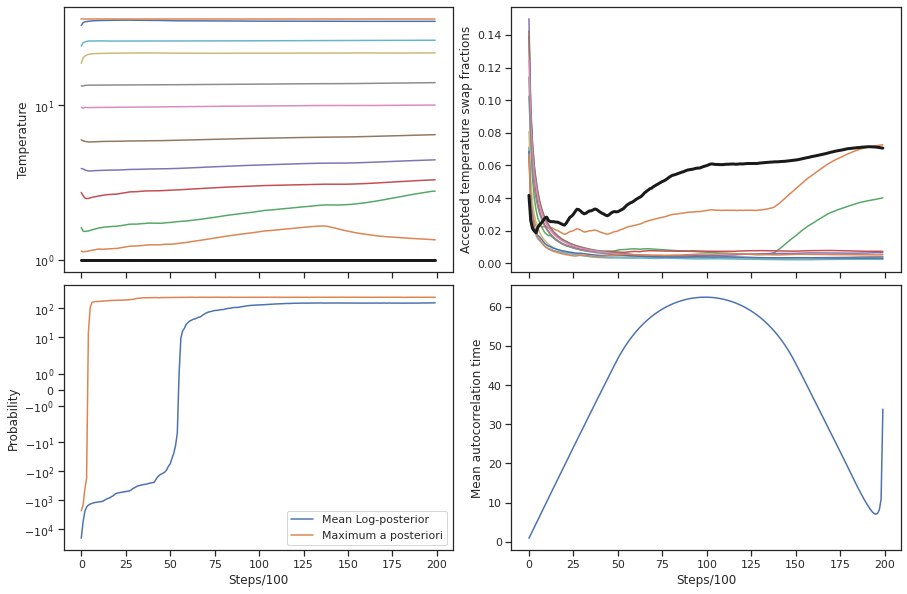

```python
nauplot.monitor(size=(15,10));
```

Plot diagnostics of convergence. It calculates the Gelman-Rubin $\hat{R}$ statistic for all the dimensions, and the Geweke test (measured with the Z-score). See for example https://rlhick.people.wm.edu/stories/bayesian_5.html

Depending on the number of iterations and chains, this figure can take many minutes to complete.

```
--> Performing Gelman-Rubin test
--> Performing Geweke test
```

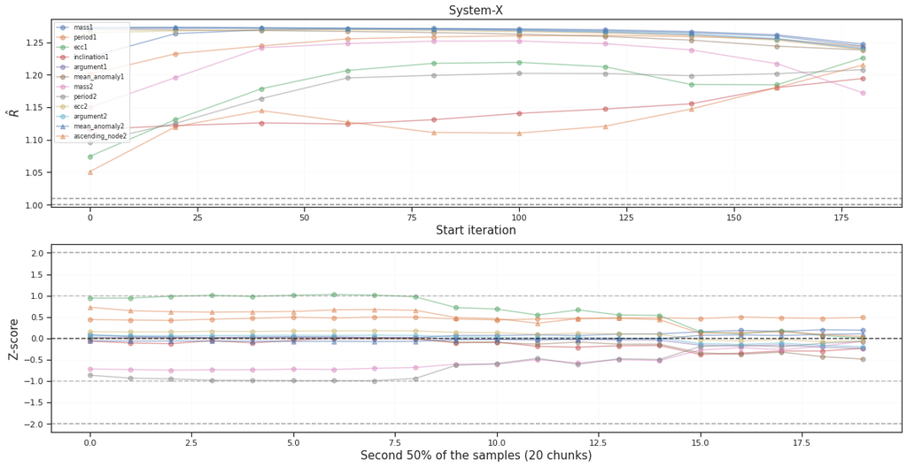

```python
# nchunks_gr is the number of chunks to divide the chains lenght in the Gelman-Rubin test
nauplot.convergence(nchunks_gr=10);
```

Does is this run converged? If not, more iterations would be needed. See restarting_mcmc example to add more iterations and see the new results.

Finally making a plot of the TTVs fitting with random solutions taken from the posteriors is an important step to assess whether the fit has been correctly carried out

```
--> plotting random solutions
```

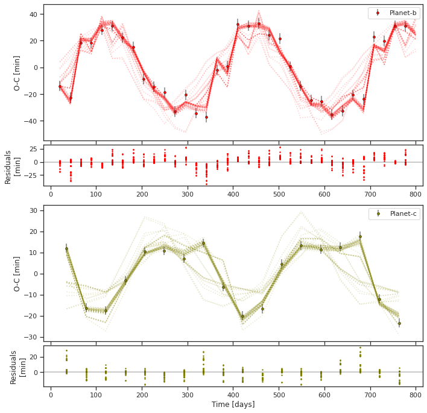

```python
nauplot.TTVs(nsols=50, mode='random', line_kwargs={'alpha':0.2, 'ls':':'});
```